# Storm Analysis: Weather Events That Affect Human Health and Damage Property and Crops

### Synopsis

This analysis takes United States weather data from 1950 to 2011 and analyzes it to determine what weather events have the greatest financial cost to agrciulture and property, and what weather events have the greatest impact on human health. Dollar values for damaged property and crops are added together into one variable showing total damage. Injuries and Fatalities are combined into one weighted variable.

### Data Processing

The first step is to begin downloading the dataset, reading it into R, and giving it the name “StormData”.

```r
library(dplyr) ; library(data.table) ; library(ggplot2); options(width=65)
if(!file.exists("./data/StormData.csv.bz2")){
        if(!file.exists("./data/")){dir.create("./data/")}
        url_data <- "https://d396qusza40orc.cloudfront.net/repdata/data/StormData.csv.bz2"
        download.file(url_data, destfile="./data/StormData.csv.bz2", method="curl")
}
```

```r
StormData <- data.table(read.csv(bzfile("./data/StormData.csv.bz2")))
```

#### Data Cleaning

**Removing Unnecessary Variables**

This data is a bit of a mess. There are 37 variables in the Storm Data, most of those are unnecessary for this analysis. The most important variables are “EVTYPE”" which indicates the type of storm event, “FATALITIES” and “INJURIES” which are self explanatory, and “PROPDMG”, “CROPDMG”, “PROPDMGEXP” and “CROPDMGEXP” which document property and crop damage.

The first step is to eliminate a bunch of these unnecessary variables. This is a full list of the variables in the raw data:

```r
names(StormData)
```

```
##  [1] "STATE__"    "BGN_DATE"   "BGN_TIME"   "TIME_ZONE"
##  [5] "COUNTY"     "COUNTYNAME" "STATE"      "EVTYPE"
##  [9] "BGN_RANGE"  "BGN_AZI"    "BGN_LOCATI" "END_DATE"
## [13] "END_TIME"   "COUNTY_END" "COUNTYENDN" "END_RANGE"
## [17] "END_AZI"    "END_LOCATI" "LENGTH"     "WIDTH"
## [21] "F"          "MAG"        "FATALITIES" "INJURIES"
## [25] "PROPDMG"    "PROPDMGEXP" "CROPDMG"    "CROPDMGEXP"
## [29] "WFO"        "STATEOFFIC" "ZONENAMES"  "LATITUDE"
## [33] "LONGITUDE"  "LATITUDE_E" "LONGITUDE_" "REMARKS"
## [37] "REFNUM"
```

I will be eliminating these variables:

```r
names(StormData)[c(9:22,29:36)]
```

```
##  [1] "BGN_RANGE"  "BGN_AZI"    "BGN_LOCATI" "END_DATE"
##  [5] "END_TIME"   "COUNTY_END" "COUNTYENDN" "END_RANGE"
##  [9] "END_AZI"    "END_LOCATI" "LENGTH"     "WIDTH"
## [13] "F"          "MAG"        "WFO"        "STATEOFFIC"
## [17] "ZONENAMES"  "LATITUDE"   "LONGITUDE"  "LATITUDE_E"
## [21] "LONGITUDE_" "REMARKS"
```

```r
StormData <- select(StormData, c(STATE__:EVTYPE, FATALITIES:CROPDMGEXP, REFNUM))
```

This cuts it down to a more manageable 15 variables.

```r
names(StormData)
```

```
##  [1] "STATE__"    "BGN_DATE"   "BGN_TIME"   "TIME_ZONE"
##  [5] "COUNTY"     "COUNTYNAME" "STATE"      "EVTYPE"
##  [9] "FATALITIES" "INJURIES"   "PROPDMG"    "PROPDMGEXP"
## [13] "CROPDMG"    "CROPDMGEXP" "REFNUM"
```

**Cleaning EVTYPE Variable**

The EVTYPE variable is troubling. It documents the type of storm event but the named events are unwieldy to put it mildly. There are variations on spelling, variation in the use of upper and lower case, typos, events that are abbreviated like TSTM, and events that should be the same but are not like Thunderstorm, THUNDERSTORM, TSTM WIND THUNDERSTORM WIND G50, and THUNDERSTORMWIND. With all these variations there are 935 different factors

This step will greatly simplify the number of weather event types slimming the 935 different factors down to 116 by standardizing spelling, case, correcting typos, and eliminating certain events that were incorrectly entered. This next step performs all these weather type aggregations and simplifications.

```r
StormData$EVTYPE <- as.character(StormData$EVTYPE)

StormData$EVTYPE <- toupper(StormData$EVTYPE)

StormData <- StormData[!grepl("SUMMARY", StormData$EVTYPE)]

StormData$EVTYPE[grepl("THU", StormData$EVTYPE) | grepl("TSTM", StormData$EVTYPE)] <- "THUNDERSTORM"

StormData$EVTYPE[grepl("SNOW", StormData$EVTYPE) ] <- "SNOW"

StormData$EVTYPE[grepl("FLOOD", StormData$EVTYPE) ] <- "FLOOD"

StormData$EVTYPE[grepl("VOLCANIC", StormData$EVTYPE) ] <- "VOLCANIC"

StormData$EVTYPE[grepl("TORN", StormData$EVTYPE) ] <- "TORNADO"

StormData$EVTYPE[grepl("LIGHTN", StormData$EVTYPE) | grepl("LIGHTING", StormData$EVTYPE) | grepl("LIGNTNING", StormData$EVTYPE) ] <- "LIGHTNING"

StormData$EVTYPE[grepl("RAIN", StormData$EVTYPE) ] <- "RAIN"

StormData$EVTYPE[grepl("FIRE", StormData$EVTYPE) ] <- "FIRE"

StormData$EVTYPE[grepl("TORN", StormData$EVTYPE) ] <- "TORNADO"

StormData$EVTYPE[grepl("HURRIC", StormData$EVTYPE) ] <- "HURRICANE"

StormData$EVTYPE[grepl("HAIL", StormData$EVTYPE) ] <- "HAIL"

StormData$EVTYPE[grepl("BLIZZARD", StormData$EVTYPE) ] <- "BLIZZARD"

StormData$EVTYPE[grepl("WINT", StormData$EVTYPE) ] <- "WINTER STORM"

StormData$EVTYPE[grepl("WINTER STORM", StormData$EVTYPE) | grepl("BLIZZARD", StormData$EVTYPE) ] <- "WINTER STORM\nBLIZZARD"

StormData$EVTYPE[grepl("TROPICAL STORM", StormData$EVTYPE) ] <- "TROPICAL STORM"

StormData$EVTYPE[grepl("TROPICAL", StormData$EVTYPE) ] <- "TROPICAL STORM"

StormData$EVTYPE[grepl("ICE", StormData$EVTYPE) | grepl("GLAZE", StormData$EVTYPE) | grepl("ICY", StormData$EVTYPE) ] <- "ICE"

StormData$EVTYPE[grepl("FLOOD", StormData$EVTYPE) | grepl("FLDG", StormData$EVTYPE) | grepl("RAPIDLY RISING WATER", StormData$EVTYPE)] <- "FLOOD"

StormData$EVTYPE[grepl("MICROBURST", StormData$EVTYPE) ] <- "MICROBURST"

StormData$EVTYPE[grepl("HAIL", StormData$EVTYPE) ] <- "HAIL"

StormData$EVTYPE[grepl("WIND", StormData$EVTYPE) ] <- "WIND"

StormData$EVTYPE[grepl("WATERSP", StormData$EVTYPE) ] <- "WATERSPOUT"

StormData$EVTYPE[grepl("COOL", StormData$EVTYPE) | grepl("COLD", StormData$EVTYPE) | grepl("HYPOTHERM", StormData$EVTYPE)] <- "COLD"

StormData$EVTYPE[grepl("HOT", StormData$EVTYPE) | grepl("WARM", StormData$EVTYPE) | grepl("HEAT", StormData$EVTYPE) | grepl("HIGH TEMP", StormData$EVTYPE) | grepl("HYPERTHERMIA", StormData$EVTYPE)] <- "HEAT"

StormData$EVTYPE[grepl("HEAVY PR", StormData$EVTYPE) | grepl("HEAVY SH", StormData$EVTYPE)] <- "THUNDERSTORM"

StormData$EVTYPE[grepl("FREEZ", StormData$EVTYPE) ] <- "FREEZE"

StormData$EVTYPE[grepl("DUST", StormData$EVTYPE) ] <- "DUST"

StormData$EVTYPE[grepl("MUD", StormData$EVTYPE) ] <- "MUDSLIDE"

StormData$EVTYPE[grepl("STREAM", StormData$EVTYPE) ] <- "STREAM FLOOD"

StormData$EVTYPE[grepl("DRY", StormData$EVTYPE) ] <- "DRY"

StormData$EVTYPE[grepl("FUNNEL", StormData$EVTYPE) ] <- "FUNNEL CLOUD"

StormData$EVTYPE[grepl("WND", StormData$EVTYPE) ] <- "WIND"

StormData$EVTYPE[grepl("DAM", StormData$EVTYPE) ] <- "DAM FAILURE"

StormData$EVTYPE[grepl("RIP CURRENT", StormData$EVTYPE) ] <- "RIP CURRENT"

StormData$EVTYPE[grepl("HIGH SURF", StormData$EVTYPE) | grepl("HEAVY SURF", StormData$EVTYPE) | grepl("ROUGH SURF", StormData$EVTYPE) | grepl("HAZARDOUS SURF", StormData$EVTYPE)] <- "HEAVY SURF"

StormData$EVTYPE[grepl("STORM SURGE", StormData$EVTYPE) ] <- "STORM SURGE"

StormData$EVTYPE[grepl("COASTALSTORM", StormData$EVTYPE) ] <- "COASTAL STORM"

StormData$EVTYPE[grepl("AVALANC", StormData$EVTYPE) ] <- "AVALANCHE"

StormData$EVTYPE[grepl("HEAVY SEAS", StormData$EVTYPE) | grepl("ROUGH SEAS", StormData$EVTYPE)] <- "ROUGH SEAS"

StormData$EVTYPE[grepl("MARINE MISHAP", StormData$EVTYPE)] <- "MARINE ACCIDENT"

StormData$EVTYPE[grepl("SLEET", StormData$EVTYPE)] <- "SLEET"

StormData$EVTYPE[grepl("FOG", StormData$EVTYPE)] <- "FOG"

StormData$EVTYPE[grepl("SWELL", StormData$EVTYPE)] <- "HIGH SWELLS"

StormData$EVTYPE <- as.factor(as.character(StormData$EVTYPE))
```

Even after all that conversion there are still 116 different types of weather events, but the most significant ones should be aggregated into a few key weather classifications.

```r
length(levels(StormData$EVTYPE))
```

```
## [1] 116
```

#### Processing Injury and Fatality Data

To study the impact of storms on human health this analysis will look for weather events that have high rates of injuries and fatalities.

The variables that indicate health impact are:

- “FATALITIES”
- “INJURIES”

There were 21929 storm events that resulted in at least one injury or fatality

```r
sum(StormData$INJURIES > 0 | StormData$FATALITIES > 0)
```

```
## [1] 21929
```

I’ll filter out all events that didn’t have any injury or fatality and create a new dataset, “StormInjuriesFatalities”, that contains just weather events that resulted in an injury or fatality.

```r
library(dplyr)

StormInjuriesFatalities <- filter(StormData, StormData$INJURIES > 0 | StormData$FATALITIES > 0)
dim(StormInjuriesFatalities)
```

```
## [1] 21929    15
```

```r
StormInjuriesFatalities$EVTYPE <- as.factor(as.character(StormInjuriesFatalities$EVTYPE))
```

**Weighted Fatalities and Injuries**

This step creates a new variable called WFI, or Weighted Fatalities and Injuries. This variable will combine injuries and fatalities into one variable and give more weight to fatalities. The formula is WFI = Fatalities * 10 + Injuries.

```r
StormInjuriesFatalities$WFI <- sapply(StormInjuriesFatalities$FATALITIES, function(x) x*10) + StormInjuriesFatalities$INJURIES
```

Using tapply I’ll aggregate the WFI variable by each storm event type and create a new dataset called WFIbyEVTYPE that shows the aggregated number WFI by each type of weather event.

```r
WFIbyEVTYPE <- tapply(StormInjuriesFatalities$WFI, StormInjuriesFatalities$EVTYPE, sum, na.rm=TRUE)
WFIbyEVTYPE <- data.table(EVTYPE = names(WFIbyEVTYPE), WFI = WFIbyEVTYPE)
```

This step adds the number of total events of each event type and adds that number to the WFIbyEVTYPE dataset under the variable “NumberOfEvents”.

```r
WFIbyEVTYPE <- arrange(WFIbyEVTYPE, desc(WFI))


for (i in 1: length(WFIbyEVTYPE$WFI)){
  WFIbyEVTYPE$NumberOfEvents[i] <- sum(StormData$EVTYPE == WFIbyEVTYPE$EVTYPE[i])
  WFIbyEVTYPE$WFIperEvent[i] <- WFIbyEVTYPE$WFI[i] / WFIbyEVTYPE$NumberOfEvents[i]
}

WFIbyEVTYPE <- WFIbyEVTYPE[WFIbyEVTYPE$NumberOfEvents >= 100]
```

```r
WFIbyEVTYPE <- arrange(WFIbyEVTYPE, desc(WFI))

p1 <- ggplot(WFIbyEVTYPE[1:10], aes(EVTYPE, WFI))
p1 <- p1 + geom_bar(stat="identity") + theme(axis.text.x = element_text(angle = 270, vjust=.5, hjust=0))
p1 <- p1 + labs(title = "Weighted Fatalities and Injuries by Weather Event Type", x="", y="Weighted Fatalities and Injuries")
```

#### Processing and Cleaning Property and Crop Damage Data

The variables that indicate economic impact are:

- “PROPDMG”
- “CROPDMG”
- “PROPDMGEXP”
- “CROPDMGEXP”

Both “PROPDMG” and “CROPDMG” give dollar values of property or crop damage. There are two other variables, “PROPDMGEXP” and “CROPDMGEXP”, that give values indicating the order of magnitude of the damage.

There were 245031 weather events that resulted in some level of property or crop damage. First I’ll make a new dataset called StormDamage that lists just those events.

```r
StormDamage <- filter(StormData, StormData$PROPDMG > 0 | StormData$CROPDMG > 0)
dim(StormDamage)
```

```
## [1] 245031     15
```

```r
StormDamage$PROPDMGEXP <- as.character(StormDamage$PROPDMGEXP)
StormDamage$CROPDMGEXP <- as.character(StormDamage$CROPDMGEXP)
```

The PROPDMGEXP and CROPDMGEXP indicate the magnitude of the damage, mostly using the variables, H, K, and M to indicated hundreds, thousands and millions. Combining PROPDMG with PROPDMGEXP and CROPDMG with CROPDMGEXP indicates how much total damage there was. For example, a 2 in the PROPDMG column, plus “H” in the PROPDMGEXP column indicates a total of $200 of property damage. 2.5 plus “K” indicates $2,500 of damage. A full key of PROPDMGEXP values is included at the bottom of this document.

To simplify this, this step will convert these letter values into their numerical equivalents and in a later step they can multiplied together to give a total dollar value of damage.

```r
StormDamage$PROPDMGEXP <- toupper(StormDamage$PROPDMGEXP)
StormDamage$CROPDMGEXP <- toupper(StormDamage$CROPDMGEXP)

StormDamage$PROPDMGEXP[grepl("K", StormDamage$PROPDMGEXP)] <- "1000"
StormDamage$PROPDMGEXP[grepl("M", StormDamage$PROPDMGEXP)] <- "1000000"
StormDamage$PROPDMGEXP[grepl("H", StormDamage$PROPDMGEXP)] <- "100"
StormDamage$PROPDMGEXP[grepl("B", StormDamage$PROPDMGEXP)] <- "1000000000"


StormDamage$CROPDMGEXP[grepl("K", StormDamage$CROPDMGEXP)] <- "1000"
StormDamage$CROPDMGEXP[grepl("M", StormDamage$CROPDMGEXP)] <- "1000000"
StormDamage$CROPDMGEXP[grepl("H", StormDamage$CROPDMGEXP)] <- "100"
StormDamage$CROPDMGEXP[grepl("B", StormDamage$CROPDMGEXP)] <- "1000000000"


StormDamage$CROPDMGEXP<- as.numeric(StormDamage$CROPDMGEXP)
StormDamage$PROPDMGEXP<- as.numeric(StormDamage$PROPDMGEXP)
```

Some of the PROPDMGEXP and CROPDMGEXP data has numbers. This step converts those numbers to factors of 10, for example a 3 will become 10^3 or 1,000.

```r
StormDamage$CROPDMGEXP[StormDamage$CROPDMGEXP == 0 & !is.na(StormDamage$CROPDMGEXP)] <- 1
StormDamage$PROPDMGEXP[StormDamage$PROPDMGEXP == 1 & !is.na(StormDamage$PROPDMGEXP)] <- 10
StormDamage$PROPDMGEXP[StormDamage$PROPDMGEXP == 2 & !is.na(StormDamage$PROPDMGEXP)] <- 100
StormDamage$PROPDMGEXP[StormDamage$PROPDMGEXP == 3 & !is.na(StormDamage$PROPDMGEXP)] <- 1000
StormDamage$PROPDMGEXP[StormDamage$PROPDMGEXP == 4 & !is.na(StormDamage$PROPDMGEXP)] <- 10000
StormDamage$PROPDMGEXP[StormDamage$PROPDMGEXP == 5 & !is.na(StormDamage$PROPDMGEXP)] <- 100000
StormDamage$PROPDMGEXP[StormDamage$PROPDMGEXP == 6 & !is.na(StormDamage$PROPDMGEXP)] <- 1000000
StormDamage$PROPDMGEXP[StormDamage$PROPDMGEXP == 7 & !is.na(StormDamage$PROPDMGEXP)] <- 10000000
StormDamage$PROPDMGEXP[StormDamage$PROPDMGEXP == 8 & !is.na(StormDamage$PROPDMGEXP)] <- 100000000

StormDamage$PROPDMGEXP[StormDamage$PROPDMGEXP == 0 & !is.na(StormDamage$PROPDMGEXP)] <- 1
```

This step replaces NA values with the number zero so they can be added in a later step without producing an error.

```r
StormDamage$CROPDMG[is.na(StormDamage$CROPDMG)] <- 0
StormDamage$CROPDMGEXP[is.na(StormDamage$CROPDMGEXP)] <- 0
StormDamage$PROPDMG[is.na(StormDamage$PROPDMG)] <- 0
StormDamage$PROPDMGEXP[is.na(StormDamage$PROPDMGEXP)] <- 0
```

This step multiplies PROPDMG with PROPDMGEXP and CROPDMG with CROPDMGEXP producing two variables indicating the total dollars of damage for each category.

```r
StormDamage$CROPDMG <- StormDamage$CROPDMG * StormDamage$CROPDMGEXP
StormDamage$PROPDMG <- StormDamage$PROPDMG * StormDamage$PROPDMGEXP
```

This step adds the crop damage and property damage into one variable, TOTALDMG

```r
StormDamage$TOTALDMG <- StormDamage$PROPDMG + StormDamage$CROPDMG
```

This step creates a new dataset “DamageByEvent” that indicates the total amount of damage by each weather event type.

```r
DamageByEvent<- tapply(StormDamage$TOTALDMG, StormDamage$EVTYPE, sum)
DamageByEvent<- data.table(EVTYPE = names(DamageByEvent), DAMAGE = DamageByEvent)
DamageByEvent<- DamageByEvent[!is.na(DamageByEvent$DAMAGE)]
DamageByEvent <- arrange(DamageByEvent, desc(DAMAGE))
```

```r
p3 <- ggplot(DamageByEvent[1:10], aes(EVTYPE, DAMAGE))
p3 <- p3 + geom_bar(stat="identity") + theme(axis.text.x = element_text(angle = 270, vjust=.5 ,hjust=0))
p3 <- p3 + labs(title = "Crop and Property Damage By Weather Event Type", y="Dollars of Damage",       x="")
```

### Results

**Injuries and Fatalities**

Tornadoes have the greatest impact on human health, followed by heat, flooding, thunderstorms, and lightning.

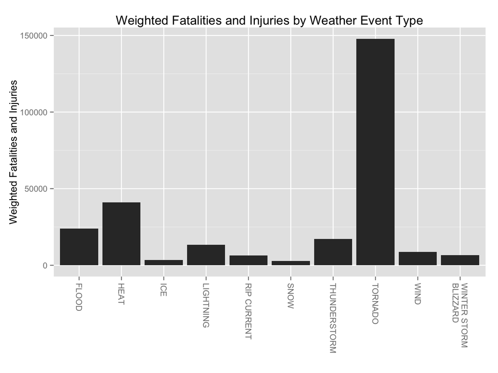

```r
p1
```

**Crop and Property Damage**

Flooding has the greatest impact on property and crop values, followed by hurricane, tornado, storm surge and hail.

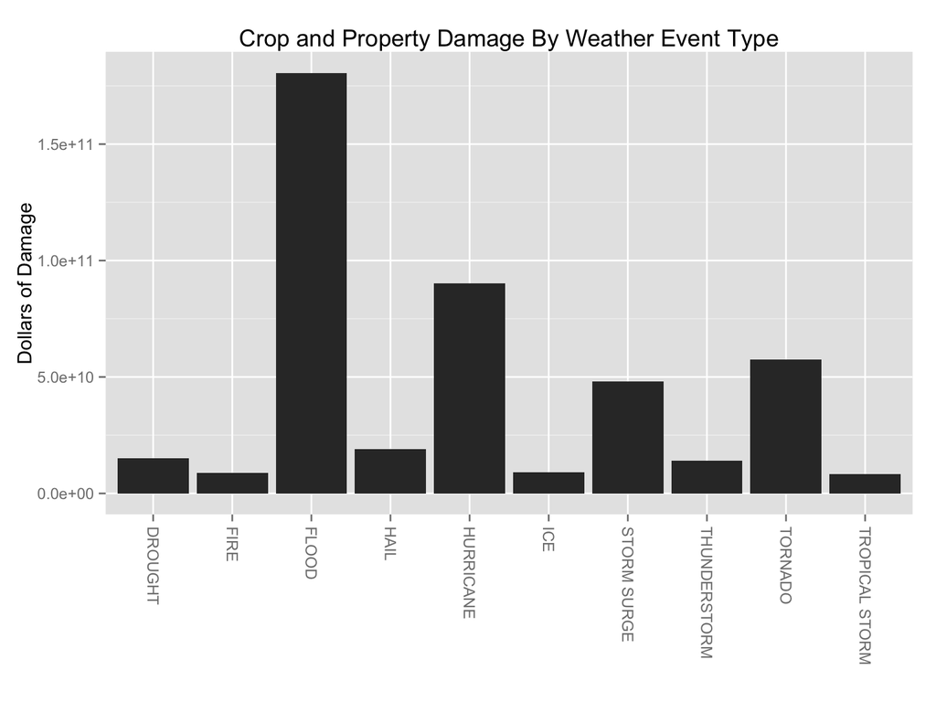

```r
p3
```

#### Footnote

##### These are possible values of CROPDMGEXP and PROPDMGEXP and how they are evaluated in this analysis:

**Possible Values**

H,h,K,k,M,m,B,b,+,-,?,0,1,2,3,4,5,6,7,8, and blank-character

**Conversion**

H,h = hundreds = 100

K,k = thousands = 1,000

M,m = millions = 1,000,000

B,b = billions = 1,000,000,000

0 = 1

1 = 10

2 = 100

3 = 1,000

4 = 10,000

5 = 100,000

6 = 1,000,000

7 = 10,000,000

8 = 100,000,000

(-) = 0

(?) = 0

blank = 0